# Simple Classification of Titanic Dataset, Take 2

David Lowe

February 14, 2018

# Introduction and Preliminary Inforamtion

Methodology Credit: Adapted from a tutorial made available by Trevor Stephens, Titanic: Getting Started With R (http://trevorstephens.com/kaggle-titanic-tutorial/getting-started-with-r/).

Template Credit: Adapted from a template made available by Dr. Jason Brownlee of Machine Learning Mastery (http://machinelearningmastery.com/).

Data Set Description: https://www.kaggle.com/c/titanic/data

Benchmark References: https://www.kaggle.com/c/titanic/leaderboard

Modeling Approach: binary classification

Working through machine learning problems from end-to-end requires a structured modeling approach. Working problems through a project template can encourage you to think about the problem more critically, to challenge your assumptions, and to get good at all parts of a modeling project.

Any predictive modeling machine learning project can be broken down into about 6 common tasks:

1. Define Problem
2. Summarize Data
3. Prepare Data
4. Evaluate Algorithms
5. Improve Accuracy or Results
6. Finalize Model and Present Results

## 1. Prepare Problem

### 1.a) Load libraries

```r
library(caret)
```

```r
library(corrplot)
```

### 1.b) Load dataset

Training Data: https://www.kaggle.com/c/titanic/download/train.csv

Test Data: https://www.kaggle.com/c/titanic/download/test.csv

```r
setwd("C:/Users/David/DEV/GitHub/r-classification-Titanic-algorithm")
training <- read.csv("train.csv", header=TRUE, sep=",", na.strings="")
```

### 1.c) Split-out validation dataset

Create a training (variable name “training”) and a validation (variable name “validation”) dataset

Normally we have only one dataset to work with. With that single dataset, we would split out a portion for training the model and the rest for validating the model. In a Kaggle competition, two datasets were provided, so there is no need to split the training dataset further.

```r
seed_num <- 8
validation <- read.csv("test.csv", header=TRUE, sep=",", na.strings="")
```

## 2. Summarize Data

To gain a better understanding of the data that we have on-hand, we will leverage a number of descriptive statistics and data visualization techniques. The plan is to use the results to consider new questions, review assumptions, and validate hypotheses that we can investigate later with specialized models.

### 2.a) Descriptive statistics

#### 2.a.i) Dimensions of the dataset.

```r
dim(training)
```

```
## [1] 891  12
```

#### 2.a.ii) Types of the attributes.

```r
sapply(training, class)
```

```
## PassengerId    Survived      Pclass        Name         Sex         Age
##   "integer"   "integer"   "integer"    "factor"    "factor"   "numeric"
##       SibSp       Parch      Ticket        Fare       Cabin    Embarked
##   "integer"   "integer"    "factor"   "numeric"    "factor"    "factor"
```

#### 2.a.iii) Peek at the data itself.

```r
head(training, n=20)
```

```
##    PassengerId Survived Pclass
## 1            1        0      3
## 2            2        1      1
## 3            3        1      3
## 4            4        1      1
## 5            5        0      3
## 6            6        0      3
## 7            7        0      1
## 8            8        0      3
## 9            9        1      3
## 10          10        1      2
## 11          11        1      3
## 12          12        1      1
## 13          13        0      3
## 14          14        0      3
```

[output cut: 48 more lines]

#### 2.a.iv) Statistical summary of all attributes.

```r
summary(training)
```

```
##   PassengerId       Survived          Pclass
##  Min.   :  1.0   Min.   :0.0000   Min.   :1.000
##  1st Qu.:223.5   1st Qu.:0.0000   1st Qu.:2.000
##  Median :446.0   Median :0.0000   Median :3.000
##  Mean   :446.0   Mean   :0.3838   Mean   :2.309
##  3rd Qu.:668.5   3rd Qu.:1.0000   3rd Qu.:3.000
##  Max.   :891.0   Max.   :1.0000   Max.   :3.000
##
##                                     Name         Sex           Age
##  Abbing, Mr. Anthony                  :  1   female:314   Min.   : 0.42
##  Abbott, Mr. Rossmore Edward          :  1   male  :577   1st Qu.:20.12
##  Abbott, Mrs. Stanton (Rosa Hunt)     :  1                Median :28.00
##  Abelson, Mr. Samuel                  :  1                Mean   :29.70
##  Abelson, Mrs. Samuel (Hannah Wizosky):  1                3rd Qu.:38.00
##  Adahl, Mr. Mauritz Nils Martin       :  1                Max.   :80.00
##  (Other)                              :885                NA's   :177
##      SibSp           Parch             Ticket         Fare
##  Min.   :0.000   Min.   :0.0000   1601    :  7   Min.   :  0.00
##  1st Qu.:0.000   1st Qu.:0.0000   347082  :  7   1st Qu.:  7.91
##  Median :0.000   Median :0.0000   CA. 2343:  7   Median : 14.45
##  Mean   :0.523   Mean   :0.3816   3101295 :  6   Mean   : 32.20
##  3rd Qu.:1.000   3rd Qu.:0.0000   347088  :  6   3rd Qu.: 31.00
##  Max.   :8.000   Max.   :6.0000   CA 2144 :  6   Max.   :512.33
##                                   (Other) :852
##          Cabin     Embarked
##  B96 B98    :  4   C   :168
##  C23 C25 C27:  4   Q   : 77
##  G6         :  4   S   :644
##  C22 C26    :  3   NA's:  2
##  D          :  3
##  (Other)    :186
##  NA's       :687
```

### 2.b) Data visualizations

#### 2.b.i) Univariate plots to better understand each attribute.

Missing data can have a significant impact on modeling. Some algorithms can work with missing data, other algorithms can break or render ineffective with missing data. The “Missingness Map” generated from the Amelia package can give us a peek into the missing data situation.

For this dataset, there are quite a few missing data for the Cabin and Age columns. We will drop the Cabin column in an effort to make the data tidy.

However, we will leave the Age attribute intact for now and analyze the models to further determine the usefulness of the Age attribute. To supply the missing Age values, we will impute the missing age field with the average age of all passengers.

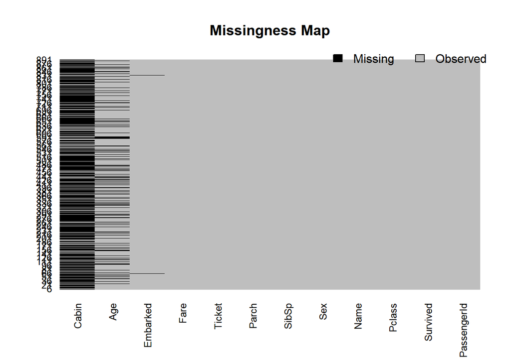

```r
library(Amelia)
missmap(training, col=c("black", "grey"))
```

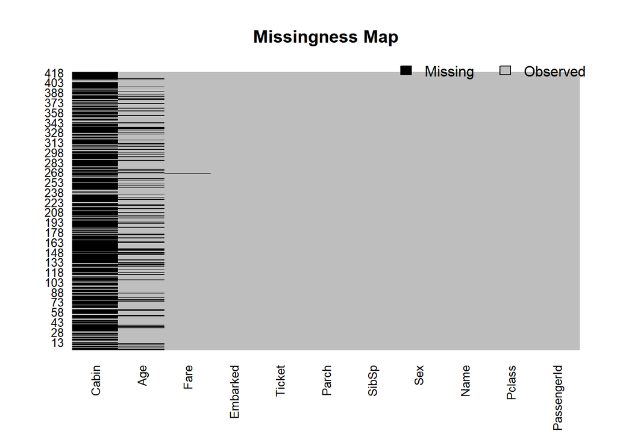

```r
missmap(validation, col=c("black", "grey"))
```

#### 2.b.ii) Multivariate plots to better understand the relationships between attributes

Since our dataset have a mixed numerical and categorical data, we will leverage the scatter plot matrix to visualize the relationship between the attributes.

For this dataset, the scatter plots did not reveal any two attribute pair that appeared to be highly correlated.

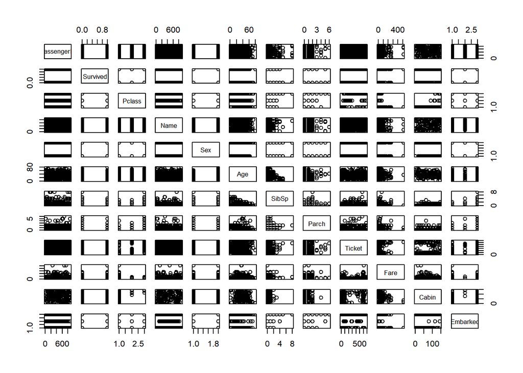

```r
pairs(training)
```

#### 2.b.iii) Examine specific attributes for potential impact to the class attribute

First, checking to see how the gender affected the survival rate

```r
summary(training$Sex)
```

```
## female   male
##    314    577
```

```r
prop.table(table(training$Sex, training$Survived))
```

```
##
##                   0          1
##   female 0.09090909 0.26150393
##   male   0.52525253 0.12233446
```

Preliminary conclusion #1: Majority of female passengers survived as expected.

Second, checking to see whether being a child (age < 18) affected the survival rate

```r
# Create a new attribute column "Child"
training$Child <- 0
training$Child[training$Age < 18] <- 1
aggregate(Survived ~ Child + Sex, data=training, FUN=sum)
```

```
##   Child    Sex Survived
## 1     0 female      195
## 2     1 female       38
## 3     0   male       86
## 4     1   male       23
```

```r
aggregate(Survived ~ Child + Sex, data=training, FUN=length)
```

```
##   Child    Sex Survived
## 1     0 female      259
## 2     1 female       55
## 3     0   male      519
## 4     1   male       58
```

```r
aggregate(Survived ~ Child + Sex, data=training, FUN=function(x) {sum(x)/length(x)})
```

```
##   Child    Sex  Survived
## 1     0 female 0.7528958
## 2     1 female 0.6909091
## 3     0   male 0.1657033
## 4     1   male 0.3965517
```

Third, checking to see whether the fare or passenger class affected the survival rate

```r
# Create bins based on fare paid
training$FareCat <- '30+'
training$FareCat[training$Fare < 30 & training$Fare >= 20] <- '20-30'
training$FareCat[training$Fare < 20 & training$Fare >= 10] <- '10-20'
training$FareCat[training$Fare < 10] <- '<10'
aggregate(Survived ~ FareCat + Pclass + Sex, data=training, FUN=function(x) {sum(x)/length(x)})
```

```
##    FareCat Pclass    Sex  Survived
## 1    20-30      1 female 0.8333333
## 2      30+      1 female 0.9772727
## 3    10-20      2 female 0.9142857
## 4    20-30      2 female 0.9000000
## 5      30+      2 female 1.0000000
## 6      <10      3 female 0.5937500
## 7    10-20      3 female 0.5813953
## 8    20-30      3 female 0.3333333
## 9      30+      3 female 0.1250000
## 10     <10      1   male 0.0000000
## 11   20-30      1   male 0.4000000
## 12     30+      1   male 0.3837209
## 13     <10      2   male 0.0000000
## 14   10-20      2   male 0.1587302
## 15   20-30      2   male 0.1600000
## 16     30+      2   male 0.2142857
## 17     <10      3   male 0.1115385
## 18   10-20      3   male 0.2368421
## 19   20-30      3   male 0.1250000
## 20     30+      3   male 0.2400000
```

Preliminary conclusion #3: Females in passenger class #3 and paid over $20 in fare appeared to have significantly lower survival rate comapred to the female survival rate in general.

## 3. Prepare Data

Some dataset may require additional preparation activities that will best exposes the structure of the problem and the relationships between the input attributes and the output variable. Some data-prep tasks might include:

- Cleaning data by removing duplicates, marking missing values and even imputing missing values.
- Feature selection where redundant features may be removed.
- Data transforms where attributes are scaled or redistributed in order to best expose the structure of the problem later to learning algorithms.

For the take #1 version of the project, I chosed to use the data as provided and see how much improvment (in accuracy and ranking) I could achieve.

### 3.a) Data Cleaning

```r
# Dropping the Name, Ticket, and Cabin columns
# The Name and Ticket values are all uniqie and directly correlated to the Passenger ID
drops <- c("Name","Ticket","Cabin")
training <- training[ , !(names(training) %in% drops)]
training$Survived <- as.factor(training$Survived)
validation <- validation[ , !(names(validation) %in% drops)]

# Dropping the temporary columns, Child and FareCat, used for data visualization
drops <- c("Child","FareCat")
training <- training[ , !(names(training) %in% drops)]
```

```r
# Imput the missing age with the average age
avg_age <- mean(training$Age, na.rm=T)
training$Age[is.na(training$Age)] <- avg_age
validation$Age[is.na(validation$Age)] <- avg_age
```

```r
# Imput the missing fare with $0
training$Fare[is.na(training$Fare)] <- 0
validation$Fare[is.na(validation$Fare)] <- 0
```

### 3.b) Feature Selection

### 3.c) Data Transforms

## 4. Evaluate Algorithms

After the data-prep, we next work on finding a workable model by evaluating a subset of machine learning algorithms that are good at exploiting the structure of the dataset. The typical evaluation tasks include:

- Defining test options such as cross validation and the evaluation metric to use.
- Spot checking a suite of linear and nonlinear machine learning algorithms.
- Comparing the estimated accuracy of algorithms.

For the take #2 version of the project, we will add the fourth and fifth iterations of experimenting with several machine learning algorithms. We will see whether the machine learning algorithms can improve our predictions.

1. Label all passengers dead or the attribute $Survived = 0 (The worst-case scenario)
2. Label all female passengers survived or the attribute $Survived = 1
3. Label all female passengers with Pclass=3 and Fare > 20 dead or the attribute $Survived = 0
4. Leverage machine learning algorithms to generate predictions
5. Tune the best-performing algorithm by experimenting various parameters

### 4.a) Test options and evaluation metric

```r
# Iteration #1
validation$Survived <- rep(0, 418)
submission <- data.frame(PassengerId=validation$PassengerId, Survived=validation$Survived)
write.csv(submission, file="submit-iteration1.csv", row.names=FALSE)
```

```r
# Iteration #2
validation$Survived[validation$Sex == 'female'] <- 1
submission <- data.frame(PassengerId=validation$PassengerId, Survived=validation$Survived)
write.csv(submission, file="submit-iteration2.csv", row.names=FALSE)
```

```r
# Iteration #3
validation$Survived[validation$Sex == 'female' & validation$Pclass == 3 & validation$Fare >= 20] <- 0
submission <- data.frame(PassengerId=validation$PassengerId, Survived=validation$Survived)
write.csv(submission, file="submit-iteration3.csv", row.names=FALSE)
```

```r
# Iteration #4
# 10-fold cross validation with 3 repeats
control <- trainControl(method="repeatedcv", number=10, repeats=3)
metric <- "Accuracy"
# LG
set.seed(seed_num)
fit.glm <- train(Survived~., data=training, method="glm", metric=metric, trControl=control, na.action=na.omit)
# LDA
set.seed(seed_num)
fit.lda <- train(Survived~., data=training, method="lda", metric=metric, trControl=control, na.action=na.omit)
# GLMNET
set.seed(seed_num)
fit.glmnet <- train(Survived~., data=training, method="glmnet", metric=metric, trControl=control, na.action=na.omit)
# KNN
set.seed(seed_num)
fit.knn <- train(Survived~., data=training, method="knn", metric=metric, trControl=control, na.action=na.omit)
# CART
set.seed(seed_num)
fit.cart <- train(Survived~., data=training, method="rpart", metric=metric, trControl=control, na.action=na.omit)
# SVM
set.seed(seed_num)
fit.svm <- train(Survived~., data=training, method="svmRadial", metric=metric, trControl=control, na.action=na.omit)
```

### 4.b) Spot Check Algorithms

For the machine learning algorithm models, we do a quick check of accuracy using just the training data.

```r
# No Transformation on the dataset
results <- resamples(list(LG=fit.glm, LDA=fit.lda, GLMNET=fit.glmnet, KNN=fit.knn, CART=fit.cart, SVM=fit.svm))
summary(results)
```

```
##
## Call:
## summary.resamples(object = results)
##
## Models: LG, LDA, GLMNET, KNN, CART, SVM
## Number of resamples: 30
##
## Accuracy
##             Min.   1st Qu.    Median      Mean   3rd Qu.      Max. NA's
## LG     0.7159091 0.7668539 0.7977528 0.7944969 0.8174157 0.8876404    0
## LDA    0.7159091 0.7668539 0.7966037 0.7956163 0.8174157 0.8764045    0
## GLMNET 0.7191011 0.7774834 0.7977528 0.7993701 0.8286517 0.8764045    0
## KNN    0.5617978 0.6260534 0.6460674 0.6463909 0.6741573 0.7303371    0
## CART   0.7415730 0.7803243 0.8089888 0.8072608 0.8314607 0.8764045    0
## SVM    0.7727273 0.7893258 0.8202247 0.8218803 0.8314607 0.8876404    0
##
## Kappa
##               Min.   1st Qu.    Median      Mean   3rd Qu.      Max. NA's
## LG     0.377123443 0.4988486 0.5643045 0.5597497 0.6128207 0.7620321    0
## LDA    0.384098544 0.4969239 0.5592700 0.5609241 0.6106236 0.7337503    0
## GLMNET 0.394887136 0.5226942 0.5643045 0.5694228 0.6314310 0.7367572    0
## KNN    0.006462985 0.1528591 0.1862132 0.1897233 0.2485335 0.3725029    0
## CART   0.430281102 0.5281750 0.5861461 0.5832342 0.6371000 0.7367572    0
## SVM    0.493087558 0.5455397 0.6112672 0.6111169 0.6400075 0.7565646    0
```

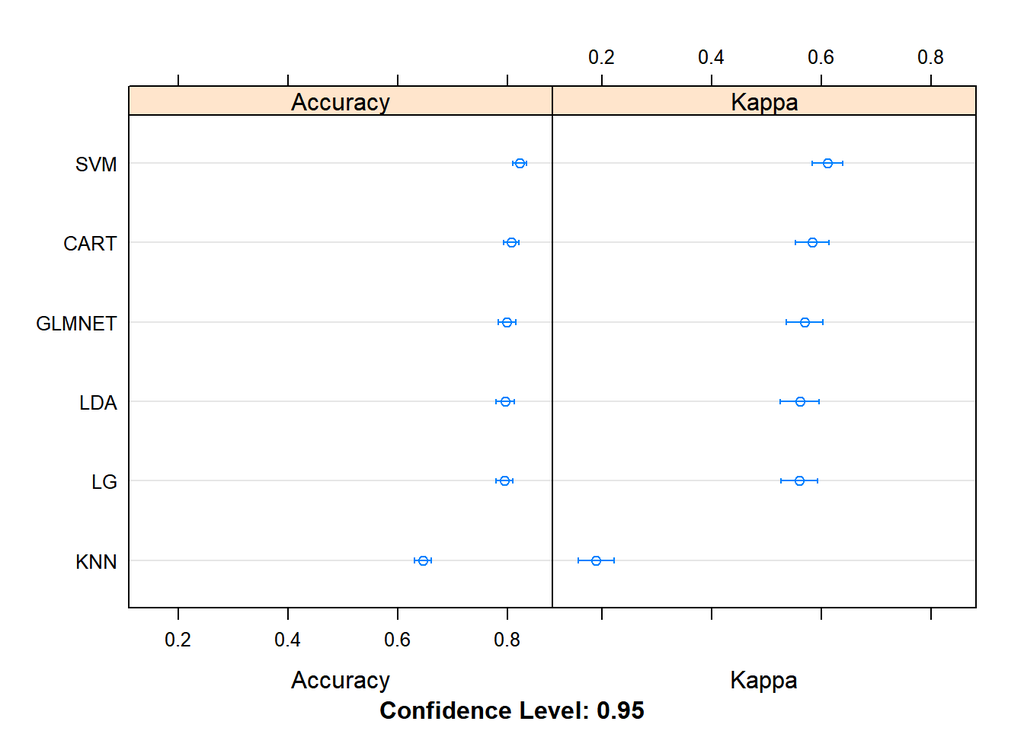

```r
dotplot(results)
```

The SVM algorithm appeared to have yield the best results with the training data, so we will submit a test result set using SVM to Kaggle for grading.

```r
# Iteration #4
predictions <- predict(fit.svm, newdata=validation)
summary(predictions)
```

```
##   0   1
## 290 128
```

```r
submission <- data.frame(PassengerId=validation$PassengerId, Survived=predictions)
write.csv(submission, file="submit-iteration4.csv", row.names=FALSE)
```

### 4.c) Compare Algorithms

Using the predictions generated from the previous sections, we submitted the predictions to Kaggle for grading.

From iteration #1, we achieved an accuracy rate of 0.62678 and a rank of 9372 out of 9652 (bottom 3%).

From iteration #2, we achieved an accuracy rate of 0.76555 and a rank of 7187 out of 9652 (bottom 25%).

From iteration #3, we achieved an accuracy rate of 0.77990 and a rank of 4786 out of 9652 (49.6% percentile).

From iteration #4, we achieved an accuracy rate of 0.78468 and a rank of 3968 out of 9666 (41.1% percentile).

## 5. Improve Accuracy

After we achieve a short list of machine learning algorithms with good level of accuracy, we can leverage ways to improve the accuracy of the models:

- Search for a combination of parameters for each algorithm using caret that yields the best results.
- Combine the prediction of multiple models into an ensemble prediction using standalone algorithms or the caretEnsemble package.

### 5.a) Algorithm Tuning

```r
set.seed(seed_num)
grid <- expand.grid(.sigma=c(0.025, 0.05, 0.1, 0.15), .C=seq(1, 10, by=1))
fit.svm <- train(Survived~., data=training, method="svmRadial", metric=metric, tuneGrid=grid, trControl=control, na.action=na.omit)
print(fit.svm)
```

```
## Support Vector Machines with Radial Basis Function Kernel
##
## 891 samples
##   8 predictor
##   2 classes: '0', '1'
##
## No pre-processing
## Resampling: Cross-Validated (10 fold, repeated 3 times)
## Summary of sample sizes: 800, 801, 800, 800, 800, 800, ...
## Resampling results across tuning parameters:
##
##   sigma  C   Accuracy   Kappa
##   0.025   1  0.8012470  0.5678440
##   0.025   2  0.8136321  0.5940362
##   0.025   3  0.8188756  0.6060862
##   0.025   4  0.8207525  0.6104741
##   0.025   5  0.8229997  0.6156204
##   0.025   6  0.8245020  0.6184452
##   0.025   7  0.8245020  0.6183297
##   0.025   8  0.8256256  0.6198936
##   0.025   9  0.8263747  0.6212497
##   0.025  10  0.8256299  0.6192876
##   0.050   1  0.8200034  0.6088059
##   0.050   2  0.8241275  0.6178480
##   0.050   3  0.8233827  0.6145611
##   0.050   4  0.8222549  0.6102048
##   0.050   5  0.8196331  0.6029049
##   0.050   6  0.8177647  0.5983152
##   0.050   7  0.8155218  0.5925102
##   0.050   8  0.8173945  0.5963548
##   0.050   9  0.8166454  0.5942078
##   0.050  10  0.8188883  0.5985686
##   0.100   1  0.8207610  0.6077728
##   0.100   2  0.8166454  0.5943365
##   0.100   3  0.8158878  0.5914885
##   0.100   4  0.8162623  0.5928659
##   0.100   5  0.8147642  0.5904058
##   0.100   6  0.8132618  0.5872034
##   0.100   7  0.8117637  0.5844051
##   0.100   8  0.8076353  0.5757651
##   0.100   9  0.8061415  0.5724291
##   0.100  10  0.8035197  0.5669018
##   0.150   1  0.8162666  0.5936527
##   0.150   2  0.8140066  0.5881572
##   0.150   3  0.8113892  0.5831360
##   0.150   4  0.8053839  0.5702739
##   0.150   5  0.8046433  0.5689181
##   0.150   6  0.8012726  0.5618664
##   0.150   7  0.7982763  0.5556413
##   0.150   8  0.7963909  0.5522474
##   0.150   9  0.7930201  0.5457333
##   0.150  10  0.7903984  0.5403970
##
## Accuracy was used to select the optimal model using the largest value.
## The final values used for the model were sigma = 0.025 and C = 9.
```

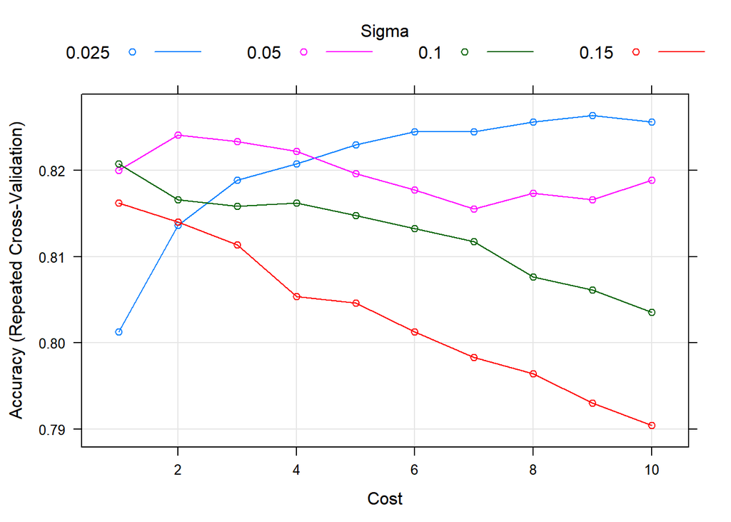

```r
plot(fit.svm)
```

### 5.b) Ensembles

## 6. Finalize Model

Once we have narrow down to a model that we believe can make accurate predictions on unseen data, we are ready to finalize it. Finalizing a model may involve sub-tasks such as:

- Using an optimal model tuned to make predictions on unseen data.
- Creating a standalone model using the tuned parameters
- Saving an optimal model to file for later use.

### 6.a) Predictions on validation dataset

```r
# Iteration #5
predictions <- predict(fit.svm, newdata=validation)
summary(predictions)
```

```
##   0   1
## 271 147
```

```r
submission <- data.frame(PassengerId=validation$PassengerId, Survived=predictions)
write.csv(submission, file="submit-iteration5.csv", row.names=FALSE)
```

From iteration #5, we achieved an accuracy rate of 0.78947 and a rank of 3047 out of 9666 (31.52% percentile).

### 6.b) Create standalone model on entire training dataset

```r
library(kernlab)
set.seed(seed_num)
finalModel <- ksvm(Survived~., data=training, kernel="rbfdot", kpar=list(sigma=0.025), C=9, na.action=na.omit)
summary(finalModel)
```

```
## Length  Class   Mode
##      1   ksvm     S4
```

### 6.c) Save model for later use